# Corrigé — Contrôle Terminal SIASS

## 1.4 Q4 — Tableau croisé V0002 × V0008

On croise le **sentiment de l’enfant face à ses enseignants** (V0002) et le **classement en difficulté scolaire** (V0008, recodage en 3 groupes : réussite, moyens, difficultés).

**NoteAstuce TCD Excel**

*Insertion > Tableau croisé dynamique* ; Lignes = V0002, Colonnes = V0008, Valeurs = V0008 (Nombre). Puis *Clic droit > Afficher les valeurs > % du total de la ligne* pour obtenir le second tableau.

**Voir le code R**

```r
# On supprime les NA et la modalité marginale "autre" (n=1)
df_cross <- df_ct %>%
  filter(!is.na(sentiment), !is.na(difficult), sentiment != "autre") %>%
  mutate(
    sentiment = factor(sentiment,
                       levels = c("à l'aise", "ça dépend", "mal à l'aise"),
                       labels = c("À l'aise", "Ça dépend", "Mal à l'aise")),
    difficult = factor(difficult,
                       levels = c("élèves en réussite", "élèves moyens", "élèves en difficultés"),
                       labels = c("Réussite", "Moyens", "Difficultés"))
  )

# --- Tableau d'effectifs ---
tab_eff <- table(df_cross$sentiment, df_cross$difficult)
tab_eff_totaux <- addmargins(tab_eff)

# Renommer "Sum" en "Total" pour les marges
dimnames(tab_eff_totaux) <- lapply(
  dimnames(tab_eff_totaux),
  function(x) gsub("^Sum$", "Total", x)
)

kable(tab_eff_totaux, caption = "Tableau 1 — Effectifs observés (avec totaux marginaux)")
```

Tableau 1 — Effectifs observés (avec totaux marginaux)

|  | Réussite | Moyens | Difficultés | Total |
| --- | --- | --- | --- | --- |
| À l’aise | 146 | 152 | 89 | 387 |
| Ça dépend | 57 | 122 | 76 | 255 |
| Mal à l’aise | 1 | 7 | 12 | 20 |
| Total | 204 | 281 | 177 | 662 |

**Voir le code R**

```r
# --- Tableau en % ligne (pourcentages par profil ligne) ---
tab_pct <- lprop(tab_eff, digits = 1)

# Renommer "All" / "Ensemble" en "total" pour les marges
dn <- dimnames(tab_pct)
dn[[1]] <- gsub("^(All|Ensemble)$", "total", dn[[1]])
dn[[2]] <- gsub("^(All|Ensemble)$", "total", dn[[2]])
dimnames(tab_pct) <- dn

kable(tab_pct, caption = "Tableau 2 — Pourcentages en ligne")
```

Tableau 2 — Pourcentages en ligne

|  | Réussite | Moyens | Difficultés | Total |
| --- | --- | --- | --- | --- |
| À l’aise | 37.72610 | 39.27649 | 22.99742 | 100 |
| Ça dépend | 22.35294 | 47.84314 | 29.80392 | 100 |
| Mal à l’aise | 5.00000 | 35.00000 | 60.00000 | 100 |
| total | 30.81571 | 42.44713 | 26.73716 | 100 |

**Lecture.** Parmi les élèves qui se sentent « mal à l’aise » avec leurs enseignants, 60 % sont classés en difficulté scolaire. À l’inverse, parmi ceux qui se sentent « à l’aise », seuls 23 % sont en difficulté et 38 % sont en réussite. On observe donc une tendance : plus le sentiment est favorable, plus la réussite scolaire est probable — mais la force de ce lien reste à tester.

## 1.5 Q5 — Test du Khi-deux

**NoteMéthode**

On cherche à savoir si les deux variables sont **dépendantes** ou **indépendantes**.

- **Sur Excel** : `=TEST.CHISQ(Plage_Observée; Plage_Théorique)` renvoie directement la p-value du test.
- **Sur R** : la fonction `chisq.test()` renvoie la p-value (et accessoirement la valeur du Khi²).

**Règle de décision** : on compare la p-value au seuil standard de 0,05.

- Si p-value **< 0,05** : on rejette l’hypothèse d’indépendance → les variables sont **dépendantes**.
- Si p-value **≥ 0,05** : on ne rejette pas l’indépendance → les variables sont **indépendantes**.

**Voir le code R**

```r
test <- chisq.test(tab_eff)
test$p.value
```

```
[1] 4.107949e-06
```

**ImportantConclusion**

La p-value est **très nettement inférieure au seuil de 0,05** (p < 0,001).

On **rejette l’hypothèse d’indépendance** : le sentiment d’aisance face aux enseignants et le classement en difficulté scolaire **sont dépendants**. Il existe un lien statistique entre les deux variables.

Attention : ce test nous dit **qu’un** lien existe, mais il ne dit rien sur sa **force** ni sur **l’endroit** où il se concentre. C’est à ces questions que répondent le V de Cramer (bonus B1) et l’analyse des résidus (Q6).

## 1.6 Q6 — Résidus standardisés et visualisation

Le test du Khi-deux nous dit qu’**un** lien existe ; les **résidus** nous disent **où** il se concentre.

**NoteFormule du résidu standardisé (Pearson)**

$$r_{ij} = \frac{O_{ij} - T_{ij}}{\sqrt{T_{ij}}}$$

**Règle du ±2** :

- $|r_{ij}| < 2$ : écart compatible avec le hasard (bruit statistique).
- $r_{ij} > +2$ : **sur-représentation** significative.
- $r_{ij} < -2$ : **sous-représentation** significative.

**Voir le code R**

```r
# Reconstruction des effectifs théoriques à partir du tableau observé
totaux_lignes <- rowSums(tab_eff)
totaux_cols   <- colSums(tab_eff)
n_total       <- sum(tab_eff)
tab_theo      <- outer(totaux_lignes, totaux_cols) / n_total

residus <- (tab_eff - tab_theo) / sqrt(tab_theo)
kable(round(residus, 2),
      caption = "Tableau 5 — Résidus standardisés")
```

Tableau 5 — Résidus standardisés

|  | Réussite | Moyens | Difficultés |
| --- | --- | --- | --- |
| À l’aise | 2.45 | -0.96 | -1.42 |
| Ça dépend | -2.43 | 1.32 | 0.95 |
| Mal à l’aise | -2.08 | -0.51 | 2.88 |

**Voir le code R**

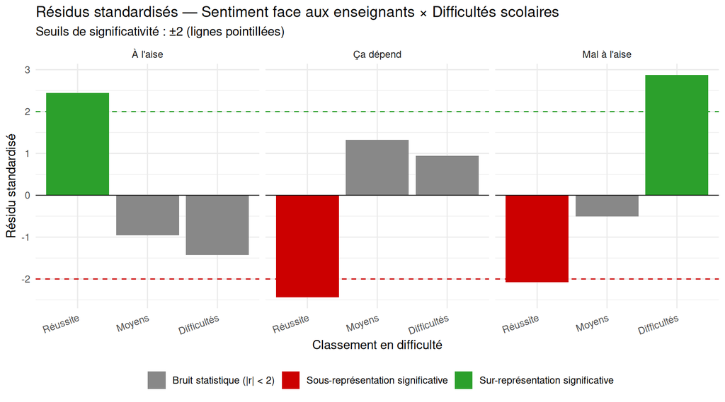

```r
df_res <- as.data.frame(as.table(residus)) %>%
  rename(Sentiment = Var1, Classement = Var2, Residu = Freq) %>%
  mutate(Sens = case_when(
    Residu >  2 ~ "Sur-représentation significative",
    Residu < -2 ~ "Sous-représentation significative",
    TRUE        ~ "Bruit statistique (|r| < 2)"
  ))

ggplot(df_res, aes(x = Classement, y = Residu, fill = Sens)) +
  geom_bar(stat = "identity") +
  geom_hline(yintercept =  2, linetype = "dashed", color = "#2ca02c") +
  geom_hline(yintercept = -2, linetype = "dashed", color = "#cc0000") +
  geom_hline(yintercept =  0, color = "black", linewidth = 0.3) +
  facet_wrap(~ Sentiment) +
  scale_fill_manual(values = c(
    "Sur-représentation significative"   = "#2ca02c",
    "Sous-représentation significative"  = "#cc0000",
    "Bruit statistique (|r| < 2)"        = "#888888"
  )) +
  labs(
    title = "Résidus standardisés — Sentiment face aux enseignants × Difficultés scolaires",
    subtitle = "Seuils de significativité : ±2 (lignes pointillées)",
    x = "Classement en difficulté",
    y = "Résidu standardisé",
    fill = ""
  ) +
  theme_minimal() +
  theme(legend.position = "bottom",
        axis.text.x = element_text(angle = 20, hjust = 1))
```

### 1.6.1 Lecture des résidus saillants

Quatre cases dépassent le seuil de ±2 :

[output not shown]

**Synthèse.** Le sentiment d’aisance relationnelle avec les enseignants est **polarisant** aux deux extrémités de la réussite : il accompagne la réussite quand il est favorable, il accompagne la difficulté quand il est défavorable.

# 2 Partie 2 : Analyse rédigée

## 2.1 Introduction

Les données sont majoritairement qualitatives et couvrent le parcours scolaire, les relations à l’école, l’environnement familial et les pratiques éducatives. Nous disposons également de quelques variables quantitatives — notamment les moyennes par matière — qui permettent d’interroger le rapport entre différents registres de talent scolaire.

## 2.2 Problématique

**Au sein de familles fortement diplômées, le talent scolaire est-il transversal entre disciplines, et le sentiment d’aisance face aux enseignants prédit-il les difficultés scolaires des collégiens ?**

Deux hypothèses sous-tendent cette problématique :

1. **Hypothèse quantitative** (Q1–Q3) : le talent scolaire est un trait global ; un élève fort en mathématiques devrait également l’être en français. Si cela se vérifie, on devrait observer une corrélation forte entre les deux moyennes.
2. **Hypothèse qualitative** (Q4–Q6) : les difficultés scolaires ne sont pas seulement cognitives mais aussi **relationnelles**. Un sentiment de malaise face aux enseignants serait associé à une plus grande probabilité d’être classé en difficulté.

## 2.3 Le talent scolaire : transversalité partielle

L’analyse bivariée français × maths apporte une **réponse nuancée** à la première hypothèse. Le coefficient de corrélation ($r = 0{,}485$) indique un lien positif et modéré : les élèves performants dans une matière le sont statistiquement plus dans l’autre, mais sans rapport systématique. Le coefficient de détermination ($R^2 = 0{,}236$) précise que **23,6 % seulement** de la variance des notes en français est expliquée par les notes en mathématiques.

Ces résultats vont à rebours d’une vision monolithique du « bon élève ». Dans ce public d’héritiers, **les compétences scolaires restent en grande partie disciplinaires**. Un élève peut parfaitement être excellent en mathématiques et faible en français, ou l’inverse. La notion de « don général pour l’école » ne résiste pas à l’analyse : elle s’apparente davantage à une construction sociale qu’à une réalité statistique.

À cela s’ajoute un constat de dispersion plus forte en mathématiques qu’en français (écart-type de 3,33 vs 2,64 ; EIQ de 5,0 vs 3,5). Les mathématiques apparaissent comme un **discriminant plus puissant** : les écarts y sont plus marqués que dans les disciplines littéraires. Cela rejoint une sociologie classique qui fait des mathématiques un domaine où les inégalités sociales se cristallisent avec une force particulière.

## 2.4 Le sentiment d’aisance au collège : un marqueur significatif des difficultés

Autrement dit, la relation pédagogique fonctionne comme un **amplificateur** : un sentiment positif accompagne la réussite ; un sentiment négatif accompagne la difficulté. Les cases intermédiaires, quant à elles, sont essentiellement neutres.

Cette polarisation invite à relire le phénomène des « héritiers en difficulté » sous un angle **relationnel** plutôt que strictement cognitif. Le capital culturel familial ne suffit pas à garantir une bonne intégration scolaire : la qualité de la relation enseignant-élève apparaît comme une **variable d’ajustement** capable d’activer ou d’inhiber les ressources héritées.

## 2.5 Conclusion

L’analyse mobilise deux registres complémentaires — quantitatif (moyennes disciplinaires) et qualitatif (sentiment relationnel) — pour éclairer la réussite scolaire dans les familles fortement diplômées. Deux résultats principaux se dégagent.

**D’une part**, le talent scolaire n’est pas un bloc homogène : la corrélation entre les moyennes en français et en mathématiques est réelle mais modérée ($r = 0{,}49$, $R^2 = 0{,}24$). Les disciplines mesurent des compétences partiellement indépendantes, et les mathématiques en particulier sont un discriminant plus puissant que le français.

**D’autre part**, le sentiment d’aisance face aux enseignants est significativement associé au classement en difficulté scolaire. Les résidus standardisés montrent une polarisation claire : le confort relationnel accompagne la réussite ; le malaise accompagne la difficulté. Si le lien est statistiquement significatif, son intensité reste cependant à qualifier (ce que permet le V de Cramer — voir bonus B1).

### 2.5.1 Limites

1. **Corrélation n’est pas causalité.** Le sentiment d’aisance peut être une **conséquence** de la réussite autant qu’une cause : les élèves en réussite sont probablement mieux traités par leurs enseignants, ce qui renforce leur aisance. On ne peut pas trancher le sens de la causalité à partir de ce seul tableau.
2. **Le sentiment déclaré est auto-rapporté.** Les collégiens (ou leurs parents) peuvent surestimer ou sous-estimer leur aisance, en fonction de biais de désirabilité.
3. **L’échantillon est spécifique** (familles fortement diplômées lyonnaises en 1999) : les résultats ne sont pas directement généralisables à l’ensemble des collégiens français.
4. **Les non-réponses** sur les moyennes scolaires (environ 30 % d’absences pour V0078 et V0084) peuvent introduire un biais de sélection si les élèves qui ne répondent pas diffèrent systématiquement des autres.

**AstuceBonne pratique**

Un rapport rigoureux conclut par **les limites** de son analyse. Rappeler que corrélation n’est pas causalité, que l’échantillon a ses biais, et que les non-réponses peuvent fausser les résultats, est un signe de maturité analytique.

# 3 Bonus

## 3.1 B1 — V de Cramer

Le V de Cramer mesure l’**intensité** de la liaison (ce que la p-value ne dit pas).

**NoteFormule**

$$V = \sqrt{\frac{\chi^2}{n \times \min(k - 1,\ l - 1)}}$$
où $k$ et $l$ sont les nombres de modalités des deux variables.

**Voir le code R**

```r
cramer_v <- cramer.v(tab_eff)
tibble(
  Indicateur = c("Khi²", "n", "min(k-1, l-1)", "V de Cramer"),
  Valeur = c(round(test$statistic, 2),
             sum(tab_eff),
             min(nrow(tab_eff) - 1, ncol(tab_eff) - 1),
             round(cramer_v, 3))
) %>% kable(align = "lr")
```

| Indicateur | Valeur |
| --- | --- |
| Khi² | 30.370 |
| n | 662.000 |
| min(k-1, l-1) | 2.000 |
| V de Cramer | 0.151 |

**ImportantInterprétation (seuils usuels en sciences sociales)**

| V de Cramer | Intensité |
| --- | --- |
| < 0,10 | effet nul ou très faible |
| 0,10 – 0,20 | **effet faible** |
| 0,20 – 0,30 | effet modéré |
| > 0,30 | effet fort |

## 3.2 B2 — PEM (Pourcentage de l’Écart Maximum)

Le PEM (Philippe Cibois) mesure, pour **une case**, la force de l’attraction par rapport à sa valeur maximale théoriquement possible compte tenu des marges.

**NoteFormule de Cibois**

Pour une case $(i, j)$ en attraction (écart positif) :

1. Écart à l’indépendance : $E = O_{ij} - T_{ij}$
2. Effectif maximum compatible avec les marges : $M = \min(\text{Total ligne}_i,\ \text{Total colonne}_j)$
3. Écart maximum : $E_{\max} = M - T_{ij}$
4. PEM (en %) : $\mathrm{PEM} = \dfrac{E}{E_{\max}} \times 100$

**Lecture :** 0 % = indépendance ; 100 % = attraction maximale compte tenu des marges.

On identifie la case la plus attractive : **“Mal à l’aise × Difficultés”**, qui présente le résidu positif le plus fort (+2,88).

**Voir le code R**

```r
# Coordonnées de la case la plus saillante
i <- which(rownames(tab_eff) == "Mal à l'aise")
j <- which(colnames(tab_eff) == "Difficultés")

O <- tab_eff[i, j]                             # observé
T <- totaux_lignes[i] * totaux_cols[j] / n_total   # théorique
E <- O - T                                     # écart à l'indépendance
M <- min(totaux_lignes[i], totaux_cols[j])     # effectif max possible
Emax <- M - T                                  # écart maximum
PEM <- E / Emax * 100

tibble(
  Étape = c(
    "Observé O",
    "Théorique T",
    "Écart E = O − T",
    "Effectif max compatible avec marges M = min(L, C)",
    "Écart maximum Emax = M − T",
    "PEM = E / Emax × 100"
  ),
  Valeur = c(
    O,
    round(T, 2),
    round(E, 2),
    M,
    round(Emax, 2),
    paste0(round(PEM, 1), " %")
  )
) %>% kable(align = "lr")
```

| Étape | Valeur |
| --- | --- |
| Observé O | 12 |
| Théorique T | 5.35 |
| Écart E = O − T | 6.65 |
| Effectif max compatible avec marges M = min(L, C) | 20 |
| Écart maximum Emax = M − T | 14.65 |
| PEM = E / Emax × 100 | 45.4 % |

**ImportantInterprétation**

**PEM ≈ 45 %** : la case “Mal à l’aise × Difficultés” atteint environ **45 % de son attraction maximale possible** compte tenu des marges. C’est un lien **non trivial** : on est à mi-chemin entre l’indépendance (0 %) et l’attraction maximale (100 %).

# 4 Annexe : Erreurs fréquentes observées dans les copies

**Important1. Ne pas commenter chaque indicateur**

La demande était explicite : chaque indicateur de Q1 devait être accompagné d’un court commentaire. Aligner huit valeurs sans les interpréter ne valide que la moitié de la question.

**Important2. Confondre p-value et force du lien**

Un test avec $p < 0{,}001$ ne signifie **pas** que le lien est « très fort » : cela signifie seulement qu’il n’est très probablement pas dû au hasard. La force du lien se mesure avec le V de Cramer (ou le PEM pour une case particulière).

**Important3. Confondre Y, $\widehat{Y}$ et X dans la régression**

Y désigne la variable à expliquer ; $\widehat{Y}$ (Y chapeau) désigne la valeur **prédite** par le modèle ; X la variable explicative. Un élève peut avoir un $\widehat{Y}$ de 13 en français alors que sa vraie note est 17 : le modèle se trompe, c’est ce qu’on appelle un résidu.

**Important4. Oublier la règle du ±2 sur les résidus**

Toute barre qui reste entre −2 et +2 est du **bruit statistique**. Seules les cases dépassant ce seuil permettent une interprétation sociologique. Sur-interpréter une barre à −0,5 est l’erreur classique.

**Important5. Conclure sans discuter les limites**

Corrélation n’est pas causalité. Un sentiment auto-rapporté est biaisé. Un échantillon spécifique n’est pas généralisable. Une analyse professionnelle se reconnaît à la lucidité de ses limites.